# GEOG 215: Assignment #6, ESDA - Spatial Clustering

Hari Potharaju

July 28, 2023

```r
# Get spatial libraries
library(tidyverse)
library(sf)
library(tmap)
library(spdep)
library(spatstat)
library(maptools)
## Load library for table styling
#library(knitr)
#library(kableExtra)
```

# Part 1, Spatial Autocorrelation ESDA

In this part of the analysis, we will be examining whether COVID-19 case rates (for cases reported over a two week period) are spatially auto correlated, and we will be identifying where there are high and low COVID-19 case rate clusters (and outliers).

## Read in North Carolina COVID data

```r
# Download, Unzip, Read in the NC School Districts Shapefile
nc.zip <- read_sf("../Data/nc_zip_mapping.shp")

## Read in COVID data
nc.covid <- read_csv("../Data/NC_ZIP_cumulative_incidence_2020-10-25.csv")

## Merge spatial and non-spatial data
nc.zip <- merge(nc.zip,
                nc.covid,
                by.x = "ZIP_CODE",
                by.y = "ZIPCODEmap")
```

## ESDA - Descriptive Statistics, Average Score

```r
####
####
#### We will be working with the column CASES14DR
#### This is the number of cases in the prior 14 days
#### divided by the number of Zip Code residents
####
####

# Number of observations
n.obs <- nrow(nc.zip)

# Number of NON-NA observations
n.good.obs <- sum(!is.na(nc.zip$CASES14DR))

# Mean of CASES per person over prior 14 days
mean.nc <- round(mean(nc.zip$CASES14DR, na.rm = TRUE), 3)

# Minimum and Maximum of CASES per person over prior 14 days
min.nc <- round(min(nc.zip$CASES14DR, na.rm = TRUE), 3)
max.nc <- round(max(nc.zip$CASES14DR, na.rm = TRUE), 3)
```

The number of observations is 749 of which 25 values have NA observations. The mean number of cases per person is 0.003 and the minimum and maximum number of cases per person is 0 and 0.033 respectively.

## ESDA - Distribution and Map

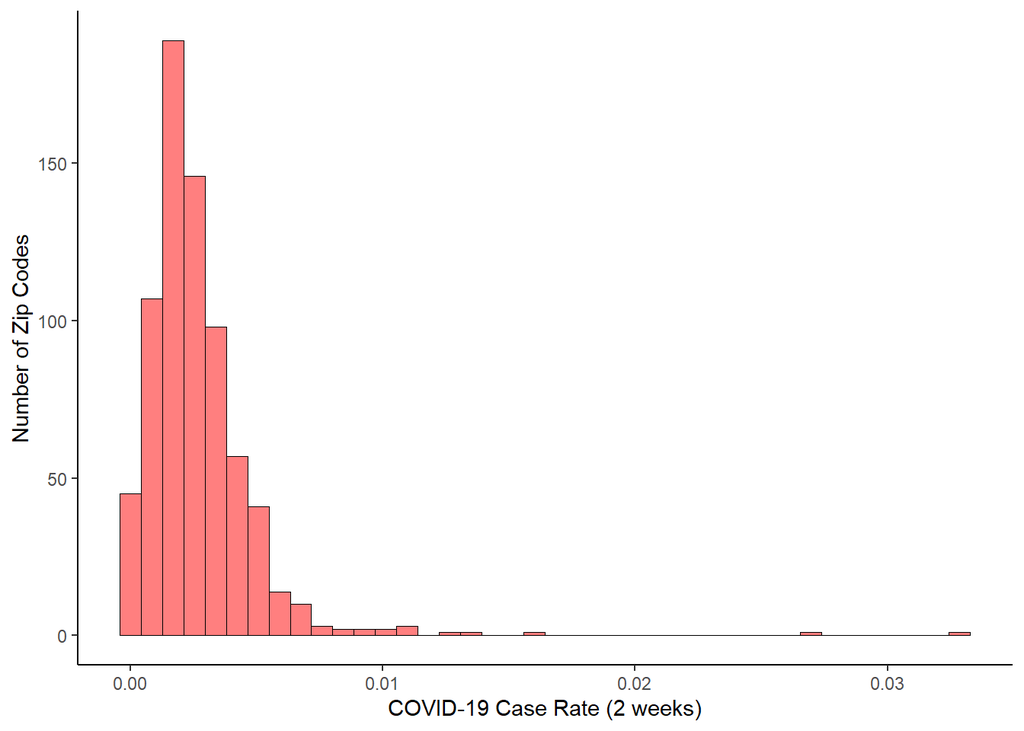

```r
# Create a histogram of CASES14DR
ggplot(nc.zip,                  ## R object
       aes(x = CASES14DR)) +    ## Column in object
  geom_histogram(na.rm = TRUE,  ## Add histogram bars without NA warning
                 bins = 40,     ## Add histogram bars
                 fill = "red",  ## Fill color of histogram bars
                 col = "black", ## Line color of histogram bars
                 size = 0.25,   ## Line weight/thickness of historam bars
                 alpha = 0.5) + ## Fill transparency
  labs(x = "COVID-19 Case Rate (2 weeks)",     ## X axis label
       y = "Number of Zip Codes") +            ## Y axis label
  theme_classic()                              ## Apply theme
```

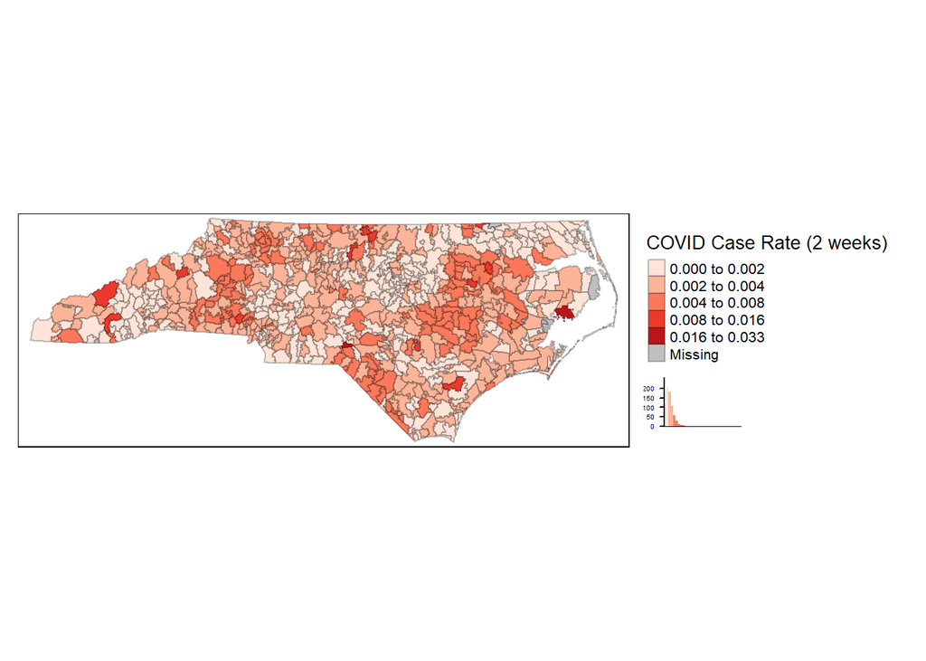

```r
# Make a quick choropleth map of CASES14DR
tm_shape(nc.zip) +
  tm_polygons("CASES14DR",
              title = "COVID Case Rate (2 weeks)",
              style = "jenks",
              palette = "Reds",
              border.col = "Black",
              border.alpha = 0.25,
              legend.hist = TRUE) +
  tm_layout(legend.outside = TRUE)
```

The histogram appears to be skewed right and peaks in number of zip codes somewhere between 0 and 0.005. There seem to be a couple of outliers that are really high compared to the rest of the data. The map shows North Carolina zip code data and appears to have a spatial pattern of clustered data.

## ESDA - Neighbors and Neighborhoods

```r
## Subset data to ONLY observations with values!
## We have to remove NAs!!
nc.zip <- nc.zip[which(!is.na(nc.zip$CASES14DR)), ]

## Create Queen case neighbors
nc.zip.nb.queen <- poly2nb(nc.zip,
                           queen = TRUE)

## Print summary to screen
nc.zip.nb.queen
```

```
## Neighbour list object:
## Number of regions: 724
## Number of nonzero links: 3928
## Percentage nonzero weights: 0.7493666
## Average number of links: 5.425414
## 1 region with no links:
## 317
```

## ESDA - Spatial Autocorrelation (Moran’s I)

```r
## Convert neighbor object to weight matrix
nc.zip.w.queen <-  nb2listw(nc.zip.nb.queen,
                            style = "B",         # B is binary (1,0)
                            zero.policy = TRUE)  # Allow obs with 0 neighbors

#
# Moran's I
#
nc.zip.moran <- moran.test(nc.zip$CASES14DR,       # Data we're analyzing
                           nc.zip.w.queen,         # Sp weights matrix
                           randomisation = TRUE,   # Compare to randomized values
                           zero.policy = TRUE)     # Allow obs with 0 neighbors

## Summary
nc.zip.moran
```

```
##
##  Moran I test under randomisation
##
## data:  nc.zip$CASES14DR
## weights: nc.zip.w.queen  n reduced by no-neighbour observations
##
##
## Moran I statistic standard deviate = 6.3043, p-value = 0.0000000001448
## alternative hypothesis: greater
## sample estimates:
## Moran I statistic       Expectation          Variance
##       0.134749567      -0.001385042       0.000466299
```

The Moran I test evaluates whether an expressed pattern is clustered, dispersed, or random and in this case there was a Moran I statistic of ~ 0.1347. This indicates that there is a pattern of clustering present in the data however because the output is very close to 0 there is only slight clustering.

## ESDA - Spatial Autocorrelation (LISA)

```r
#
# LISA -- Local Moran's I
#
nc.zip.lisa <- localmoran(nc.zip$CASES14DR,        # The column in your sp data
                          nc.zip.w.queen,          # Weights object
                          zero.policy = TRUE) %>%  # Best to keep TRUE for LISA
  as.data.frame()  # Make result into data frame

## To get "nice" LISA categories for mapping
## takes a bit of work in R, unfortunately

# Scale the input data to deviation from mean
cDV <- nc.zip$CASES14DR - mean(nc.zip$CASES14DR)

# Get spatial lag values for each observation
# These are the neighbors' values!
lagDV <- lag.listw(nc.zip.w.queen, nc.zip$CASES14DR)

# Scale the lag values to deviation from mean
clagDV <- lagDV - mean(lagDV, na.rm = TRUE)

# Add holder column with all 0s
nc.zip.lisa$Cat <- rep("0", nrow(nc.zip.lisa))

# This simply adds a label based on the values
nc.zip.lisa$Cat[which(cDV > 0 & clagDV > 0 & nc.zip.lisa[,5] < 0.05)] <- "HH"
nc.zip.lisa$Cat[which(cDV < 0 & clagDV < 0 & nc.zip.lisa[,5] < 0.05)] <- "LL"
nc.zip.lisa$Cat[which(cDV < 0 & clagDV > 0 & nc.zip.lisa[,5] < 0.05)] <- "LH"
nc.zip.lisa$Cat[which(cDV > 0 & clagDV < 0 & nc.zip.lisa[,5] < 0.05)] <- "HL"

## Quick SUMMARY of LISA output
table(nc.zip.lisa$Cat)
```

```
##
##   0  HH  LH  LL
## 672  33  13   6
```

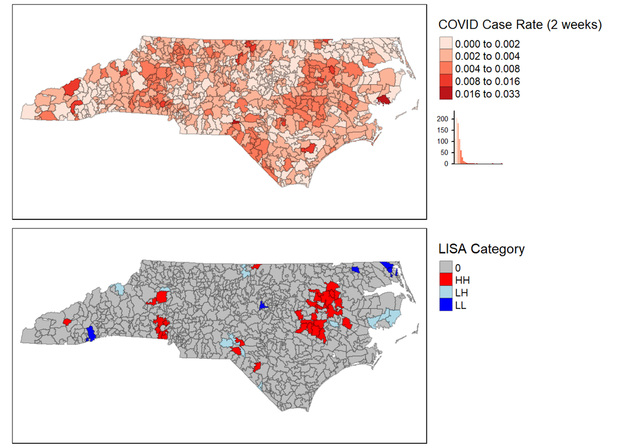

```r
## Add LISA category column to the spatial data
## for mapping!
nc.zip$LISACAT <- nc.zip.lisa$Cat

# Plot two maps together!
# First, the chorolpleth map
covid.tmap <- tm_shape(nc.zip) +
  tm_polygons("CASES14DR",
              title = "COVID Case Rate (2 weeks)",
              style = "jenks",
              palette = "Reds",
              border.col = "Black",
              border.alpha = 0.25,
              legend.hist = TRUE) +
  tm_layout(legend.outside = TRUE)
# Second the LISA map
lisa.tmap <- tm_shape(nc.zip) +
  tm_polygons("LISACAT",
              title = "LISA Category",
  #            style = "cat",
              palette = c("0" = "grey",
                          "HH" = "red",
  #                        "HL" = "lightred",
                          "LL" = "blue",
                          "LH" = "lightblue"),
              border.col = "Black",
              border.alpha = 0.25) +
  tm_layout(legend.outside = TRUE)
# This command maps them together!
tmap_arrange(covid.tmap, lisa.tmap)
```

```r
### For LISA mapping above, use the following pallette
### option if you have observations in all four LISA
### categories (plus 0s)
#              palette = c("0" = "grey",
#                          "HH" = "red",
#                          "HL" = "lightred",
#                          "LL" = "blue",
#                          "LH" = "lightblue")
```

The LISA results show that there are areas of the map that have some clustering, there is mostly high-high clustering which means that observations with high values are surrounded with neighbors that also have high values. While the results show that there is definitely some clustering, as the Moran I test previously indicated, there is only slight clustering. A majority of the map is filled with grey space which shows that those areas don’t have a significant pattern or any form of clustering.

# Part 2, Spatial Cluster Analysis, Point Data

In this part of the analysis, we will be examining 311 Case reports of human or animal waste in San Francisco (using data from 2020). [Read more about the data here](https://data.sfgov.org/City-Infrastructure/311-Cases/vw6y-z8j6). A number of news stories have reported on the city’s struggles with providing services and care for their homeless population[^1]. Specifically, there are a lack of public restrooms that are made available to the city’s homeless population.

## Read in San Francisco 311 data

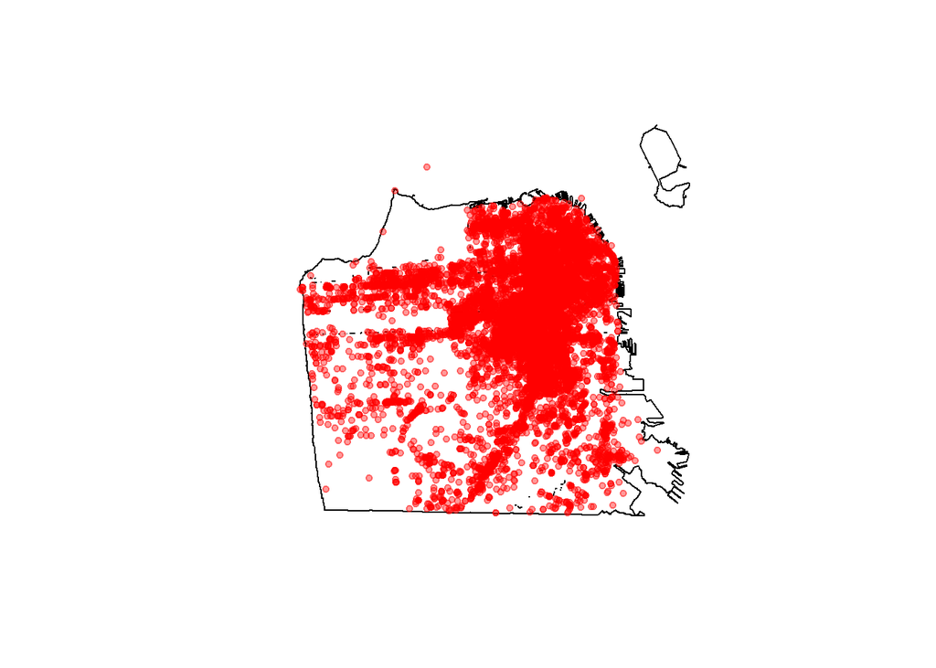

```r
## Read in SF 311 reports of human or animal waste
sf.waste <- read_csv("../Data/SF_311_Cases_human_animal_waste_2020.csv")

## Convert to sf object
sf.waste <- st_as_sf(sf.waste,
                     coords = c("Longitude",
                                "Latitude"),
                     crs = 4326)   ## WGS 84

## Read in shapefile of SF neighborhoods
sf.bound <- read_sf("https://data.sfgov.org/api/geospatial/p5b7-5n3h?method=export&format=GeoJSON")

##
## Aggregate (dissolve neighborhood boundaries)
##
## First, add a column to aggregate, then aggregate
sf.bound$area <- st_area(sf.bound)
sf.bound <- sf.bound %>%
  summarise(area = sum(area))

## Reproject data to a Projected Coordinate System
## CA State Plane, Zone 3 (meters)
sf.waste <- st_transform(sf.waste, crs = 26943)
sf.bound <- st_transform(sf.bound, crs = 26943)

## Quick plot
plot(st_geometry(sf.bound))
plot(st_geometry(sf.waste),
     pch = 20,
     col = rgb(1, 0, 0, 0.4),
     add = TRUE)
```

```r
## Clip points only those inside boundary
sf.waste <- st_join(sf.waste,
                    sf.bound,
                    left = FALSE) # This parameter subsets to those "inside"
```

## ESDA - Descriptive Statistics

```r
## Basic ESDA information for incidents
## Get number of observations
n.obs <- nrow(sf.waste)
n.obs
```

```
## [1] 21985
```

```r
## Get density = observations / area
# Calculate density per square km (not square meters)
sf.waste.density <- n.obs / (st_area(sf.bound) / 1000000)
as.numeric(sf.waste.density) # reports per km^2
```

```
## [1] 180.0654
```

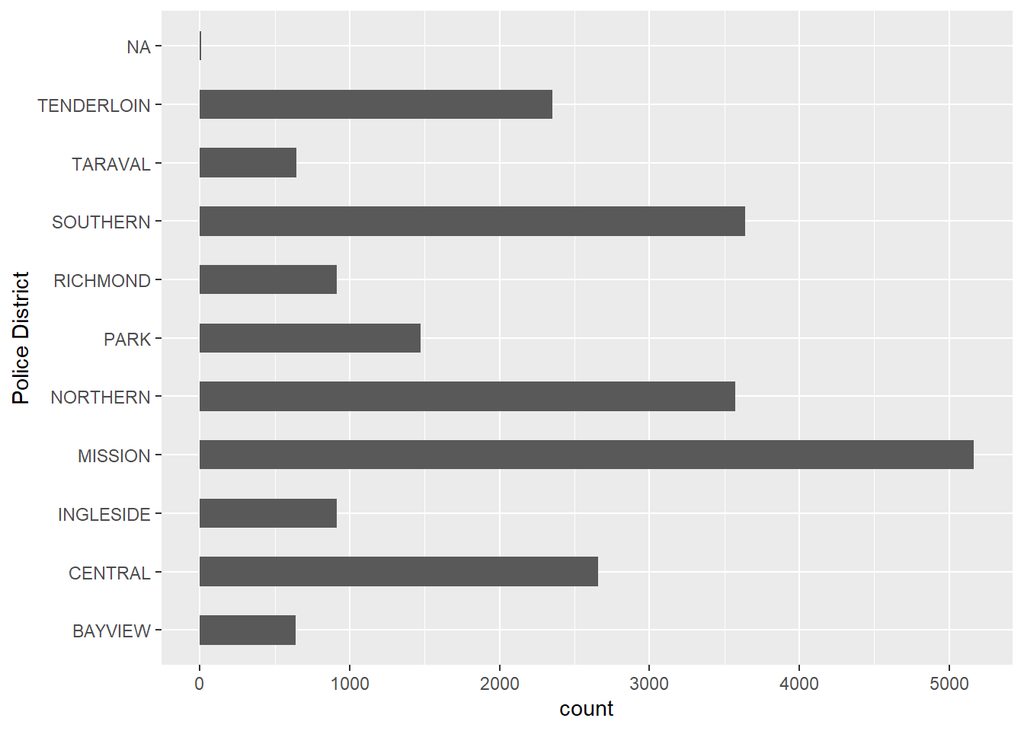

```r
## Barplot of Status
ggplot(data = sf.waste,
       aes(x = `Police District`)) +
  geom_bar(stat = "count",
           width = 0.5) +
  coord_flip()
```

The horizontal bar graph shows the various police districts in San Francisco and the number of human or animal waste case reports there are in each district. The district with the most cases is Mission with more then 5000 cases reported and the least (excluding NA) is Bayview with less then 1000 reports. The number of reports per square kilometer is approximately 180.07.

## Quadrat Analysis

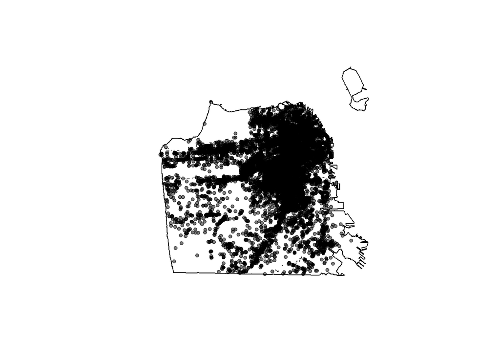

```r
## First, get the data in the proper format to use the
## spatstat pont pattern analysis functions
## Convert to ppp format
sf.waste.ppp <- as(sf.waste, "Spatial") %>% as("ppp")

## Note that these are UNMARKED points
marks(sf.waste.ppp) <- NULL

## Provide data with the STUDY AREA bounds as a window
Window(sf.waste.ppp) <- as(sf.bound, "Spatial") %>% as("owin")

## Plot the layer to ensure that the boundary is properly defined
plot(sf.waste.ppp,
     main = NULL,
     cols = rgb(0, 0, 0, 0.5),
     pch = 20)
```

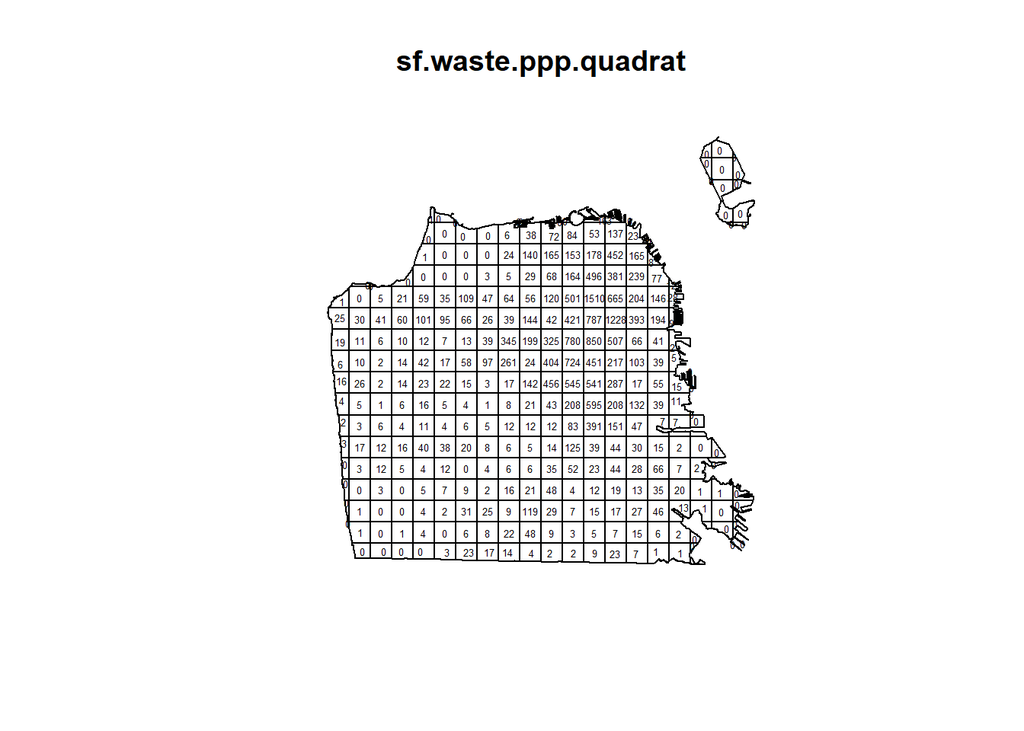

```r
## Create Quadrat Counts
## We will use the same number of rows and columns,
## given the shape of SF
sf.waste.ppp.quadrat <- quadratcount(sf.waste.ppp,
                                     nx = 20,
                                     ny = 20)

## Plot the quadrat counts
plot(sf.waste.ppp.quadrat,
     cex = 0.4)              ## Controls size of text
```

```r
#
# Perform the quadrat test
# Use nx = 20 and ny = 20
#
sf.waste.ppp.quadrat.test <- quadrat.test(sf.waste.ppp,
                                          nx = 20,
                                          ny = 20)

## Calculate and print Variance to Mean Ratio
sf.waste.VMR <- var(sf.waste.ppp.quadrat.test$observed) / mean(sf.waste.ppp.quadrat.test$observed)
sf.waste.VMR
```

```
## [1] 429.3439
```

```r
## Print test results to screen
sf.waste.ppp.quadrat.test
```

```
##
##  Chi-squared test of CSR using quadrat counts
##
## data:  sf.waste.ppp
## X2 = 105716, df = 302, p-value < 0.00000000000000022
## alternative hypothesis: two.sided
##
## Quadrats: 303 tiles (irregular windows)
## Tessellation is marked
```

The quadrat test examines the spatial distribution of point data and sectioned the study region into 303 quadrats to evaluate the variance among regions.The VMR or variance to mean ration is 429.3439. Because the VMR is greater than 1, this indicates that the data is much more clustered then random.

## Nearest Neighbor Analysis

```r
##
## Calculate the expected NND for a randomly distributed
## set of points in our study area
##

# Get the area measure and perimeter length of Durham County
sf.area <- st_area(sf.bound)
# Perimeter is a bit more difficult because of complex polygon
sf.per <- st_cast(sf.bound, "MULTILINESTRING") %>%
  st_cast("LINESTRING") %>%
  st_length() %>%
  sum()
# Warning is okay

## Now, calculate theoretical Nearest Neighbor Distance for random
nnd.random <- sqrt(sf.area/n.obs)/2 + (0.0514 + (0.041/(sqrt(n.obs))))*(sf.per/n.obs)
## And, calculate the variance for random
sigma.nnd.random <- sqrt(((0.07*sf.area)/n.obs^2) + 0.037*sf.per*sqrt(sf.area/n.obs^5))

## Print
nnd.random
```

```
## 37.63288 [m]
```

```r
sigma.nnd.random
```

```
## 0.1363263 [m]
```

```r
## The average Nearest Neighbor distance of
## human or animal waste randomly distributed throughout
## SF would be 37.7 meters (with variance of 0.14 meters)

##
## Calculate Nearest Neighbor Distance (NND) for observed data
##
## There is a function for NND in spatstat
sf.waste.ppp.NND <- nndist(sf.waste.ppp)

## Now, get the mean of the NND and print to screen
NND <- mean(sf.waste.ppp.NND)
NND
```

```
## [1] 15.22952
```

```r
## Calculate Z score of test
z.score.NND <- (NND - as.numeric(nnd.random)) / as.numeric(sigma.nnd.random)
z.score.NND
```

```
## [1] -164.3363
```

```r
## Calculate p-value of test
pt(z.score.NND, n.obs-1)
```

```
## [1] 0
```

```r
## Here 0 is very low, means highly statistically significant
```

Similarly to the quadrat test, the results of the Nearest Neighbor Distance test shows that the data is more clustered then it is random. The NND is ~ 15.2 and random is ~ 37.6, because the NND is smaller then random we can assume that the data is more clustered then random. Additionally, because we have a negative Z-score we can come to the same conclusion.

## Use Kernel Density (to make a quick, decent looking map)

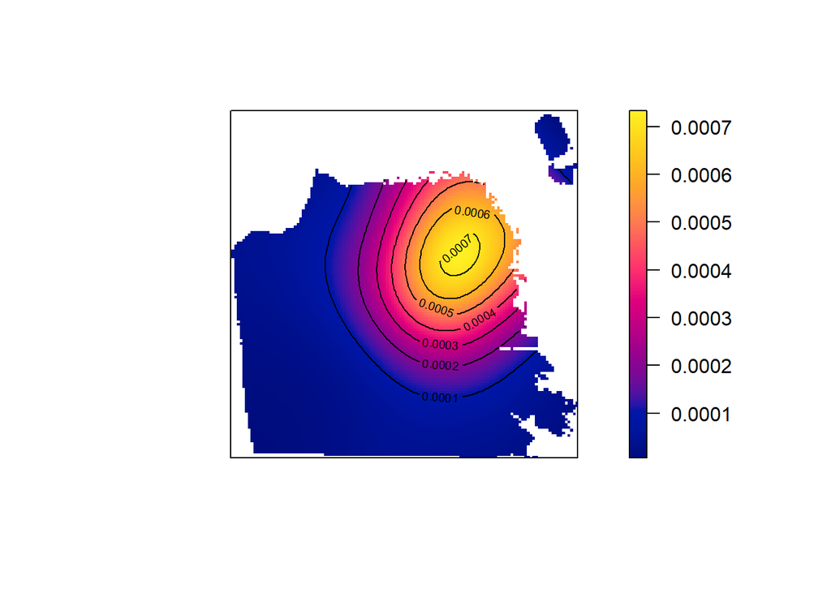

```r
## Kernel density function using default bandwidth
k1 <- density(sf.waste.ppp)

## Make a continuous map of intensity/density
plot(k1,
     main = NULL,
     las = 1)
contour(k1,
        add = TRUE)
```

[^1]: e.g., https://www.businessinsider.com/san-francisco-human-poop-problem-2019-4, https://www.vice.com/en_us/article/a3xdae/more-people-pooping-in-san-francisco-than-ever-all-time-high-vgtrn, https://sfist.com/2019/05/01/a-brief-history-of-poop-on-the-streets-of-san-francisco/